# Cohort Analysis + LTV:CAC (Marketing Analytics Case Study)

by Konrad Kuleta

The following analysis uses a synthetic e-commerce dataset to answer:

- **Retention:** What share of customers return in months 1–12 after their first purchase?
- **LTV:** How does cumulative revenue per customer evolve over the first 12 months?
- **Unit economics:** How does **LTV:CAC** compare across acquisition channels?

## Key assumptions

- **LTV proxy:** LTV is approximated using a constant **45% contribution margin** applied to net revenue.
- **Organic:** Organic has **0 recorded spend** in this dataset, so **CAC is not applicable** for Organic.

## Cohort Heatmap

Data is loaded from pre-cleaned CSV files and transformed into cohort features (cohort_month, cohort_index). Definitions:

- **cohort_month**: month of a customer's **first** purchase
- **order_month**: month of a given order
- **cohort_index**: number of months since first purchase (0, 1, 2, ...)

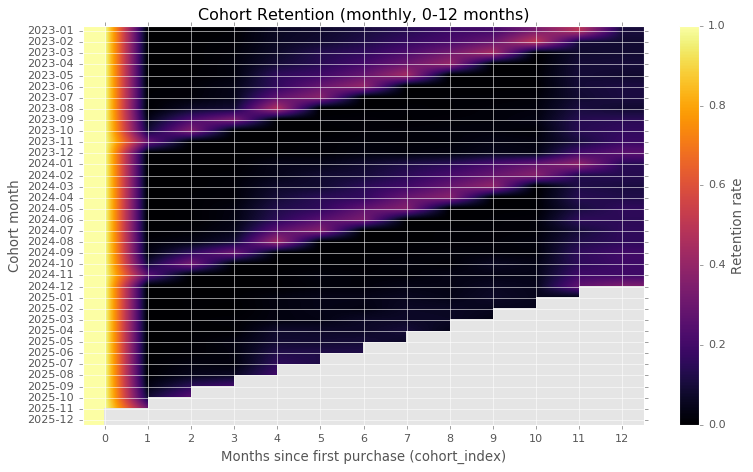

## Cumulative revenue per cohort

- Cumulative sum across months → **cumulative revenue**

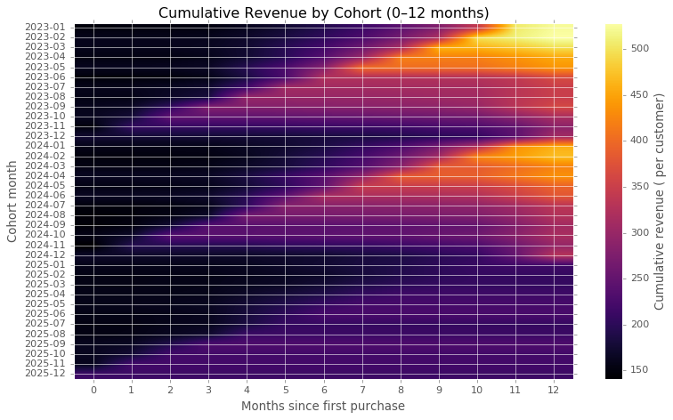

## LTV:CAC by acquisition channel

CAC is calculated from **media spend / new customers** (per month & channel). Then, for each channel, 2024 cohorts are summarized and computed:

- **avg CAC** (2024)
- **avg LTV after 12 months** (revenue-based)
- **LTV:CAC** (revenue-based)
- **LTV:CAC** with **margin proxy** (45%)

|  | channel | avg_CAC_2024 | avg_LTV12_2024 | LTV:CAC_12m_revenue | LTV:CAC_12m_margin45 |
| --- | --- | --- | --- | --- | --- |
| 0 | Affiliate | 60.664859 | 391.367844 | 6.451311 | 2.903090 |
| 1 | Email | 68.532846 | 372.669731 | 5.437827 | 2.447022 |
| 4 | Paid Social | 71.923793 | 381.274949 | 5.301096 | 2.385493 |
| 3 | Paid Search | 84.522407 | 360.202875 | 4.261626 | 1.917732 |
| 2 | Organic | 0.000000 | 371.697546 | NaN | NaN |

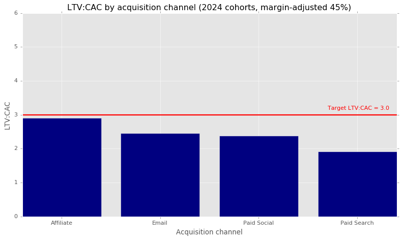

## Summary

**Recommendations:**

- Scale what’s closest to target: Prioritize channels with the highest margin-adjusted LTV:CAC (Affiliate / Email / Paid Social) while monitoring diminishing returns.
- Fix the weakest link (Paid Search): Improve unit economics via: a) **CAC reduction**: keyword and query refinement, landing page improvements, ad/creative testing, negative keywords, better intent segmentation. b) **LTV uplift**: bundles, subscriptions, post-purchase cross-sell, lifecycle email flows that target the first 90 days (where retention drops most).

**Limitations:**

- **Margin proxy**: Contribution margin is assumed constant (45%) to approximate LTV in a margin-adjusted scenario.
- **Organic CAC not observed**: Organic has 0 recorded spend in the dataset, so CAC is not comparable for Organic.
- **Synthetic dataset**: Patterns are simulated and may lack real-world noise and attribution complexity.

## Appendix: Sanity checks

```
Orders 2025: 20000
Revenue 2025: 3133059.43
Spend 2025: 380000.02
```